# Cases Per Million for (0-9) month age-group (adjusted for age-wise population).

##Calculating the percentage of cases per million with respect to the case classification EPI Linked and Lab confirmed

```r
totalcases_EL_LC <- function(df, df_state, df_year){


  age_categories_filter <- c("0-3 months",  "(3-6] months", "(6-9) months", "[9-12] months", "(1-2] years", "(2-3] years", "(3-4] years", "(4-5] years", "(5-10] years", "(10-15] years", "15+ years" )
  case_classification = c( "EPI LINKED MEASLES", "LAB CONFIRMED MEASLES")
  df=subset(df, Age_category  %in%  age_categories_filter & `Case Classification` %in% case_classification)

  # Filter and aggregate the data
  df <- df %>%
    group_by(Age_category) %>%    # Group by age category and case classification
    summarise(Total_Value = sum(Count), .groups = 'drop') # Summarize the data


  #Adding total population for a particula state w.r.t. age startification
  df <- merge(df, Tot_Pop, by = "Age_category")

  #Calculating the proportion
  df$Cases_Per_Population <- df$Total_Value/df$Population

  #Calculating cases per million
  df$Cases_Per_Million <- df$Cases_Per_Population*1000000

  #Calculating the pecentage of cases per million adjusted for age-wise population
  df$Cases_Percent <- df$Cases_Per_Million/sum(df$Cases_Per_Million)*100

  df=df%>%mutate(state=df_state)
  df=df%>%mutate(year=df_year)

  #print(sum(df$Cases_Percent))

  #Arranging the data in increasing order with respect to the age category
  custom_order <- c("0-3 months",  "(3-6] months", "(6-9) months", "[9-12] months", "(1-2] years", "(2-3]                         years", "(3-4] years", "(4-5] years", "(5-10] years", "(10-15] years", "15+ years" )

  # Convert Age_category to a factor with the custom order
  df$Age_category <- factor(df$Age_category, levels = custom_order)

  # Sort the data frame based on the custom order
  df <- df %>% arrange(Age_category)



  return(df)

}

df_17_tot_EL_LC <- totalcases_EL_LC(df_17, state_name,2017)
df_18_tot_EL_LC <-totalcases_EL_LC(df_18,state_name, 2018)
df_19_tot_EL_LC <- totalcases_EL_LC(df_19,state_name, 2019)
df_20_tot_EL_LC <-totalcases_EL_LC(df_20, state_name,2020)
df_21_tot_EL_LC <- totalcases_EL_LC(df_21,state_name, 2021)
df_22_tot_EL_LC <- totalcases_EL_LC(df_22, state_name,2022)
df_23_tot_EL_LC <-totalcases_EL_LC(df_23,state_name, 2023)
df_24_tot_EL_LC <-totalcases_EL_LC(df_24, state_name,2024)

#Joining the data to save it into the excel file
df_total_EL_LC <- bind_rows(df_17_tot_EL_LC,df_18_tot_EL_LC, df_19_tot_EL_LC, df_20_tot_EL_LC, df_21_tot_EL_LC, df_22_tot_EL_LC, df_23_tot_EL_LC, df_24_tot_EL_LC)

# Write the data frames to an Excel file with specified tab names
file_name="Maharashtra.xlsx"
write_xlsx(df_total_EL_LC, path = file_name)
```

##Calculating the percentage of cases per million for age group 0-9 months.

```r
tot_0_9_EL_LC <- function(df){

 age_categories_filter <- c("0-3 months",  "(3-6] months", "(6-9) months")
 # Filter and aggregate the data
 df <- df %>%
   filter(Age_category %in% age_categories_filter) %>% # Filter specific age categories
   group_by(Age_category) %>%    # Group by age category and case classification
   summarise(Total_Percent_09 = sum(Cases_Percent), .groups = 'drop') # Summarize the data

 xx=sum(df$Total_Percent_09)
 return(xx)
}

df_17_0_9_EL_LC <- round(tot_0_9_EL_LC(df_17_tot_EL_LC))
df_18_0_9_EL_LC <- round(tot_0_9_EL_LC(df_18_tot_EL_LC))
df_19_0_9_EL_LC <- round(tot_0_9_EL_LC(df_19_tot_EL_LC))
df_20_0_9_EL_LC <- round(tot_0_9_EL_LC(df_20_tot_EL_LC))
df_21_0_9_EL_LC <- round(tot_0_9_EL_LC(df_21_tot_EL_LC))
df_22_0_9_EL_LC <- round(tot_0_9_EL_LC(df_22_tot_EL_LC))
df_23_0_9_EL_LC <- round(tot_0_9_EL_LC(df_23_tot_EL_LC))
df_24_0_9_EL_LC <- round(tot_0_9_EL_LC(df_24_tot_EL_LC))
```

##To plot the data mergeing the above calculated percentage into single data frame.

```r
df_EL_LC=rbind.data.frame(df_17_0_9_EL_LC, df_18_0_9_EL_LC, df_19_0_9_EL_LC, df_20_0_9_EL_LC, df_21_0_9_EL_LC, df_22_0_9_EL_LC, df_23_0_9_EL_LC, df_24_0_9_EL_LC )
colnames(df_EL_LC)[1] <- "Total_Cases_0_9_EL_LC"
df_EL_LC$Year1=c("2017", "2018", "2019", "2020", "2021", "2022", "2023", "2024")
df_EL_LC$Year1 <- as.numeric(df_EL_LC$Year1)
colnames(df_EL_LC)[2] <- "Year_1"
```

##Trend Line plot for the age group 0-9 months and case classification - EPI Linked and Lab confirmed.

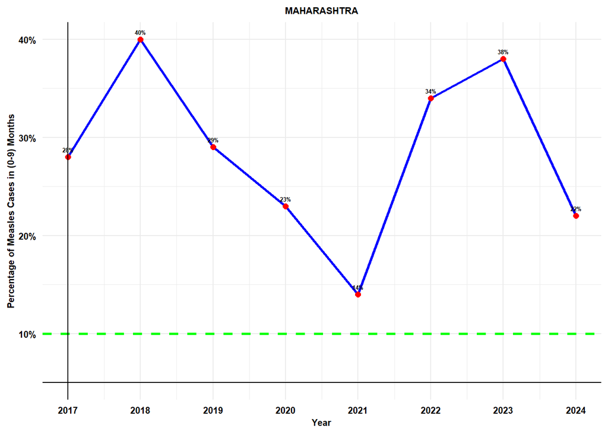

```r
#Create the line plot
plot <- ggplot(df_EL_LC, aes(x = Year_1, y = Total_Cases_0_9_EL_LC)) +
  geom_line(size = 1, color = "blue") +
  geom_point(size = 2, color = "red") +
  labs(
    title = title1,
    x = "Year",
    y = "Percentage of Measles Cases in (0-9) Months"
  ) +
  theme_minimal() +
  theme(
    axis.title.x = element_text(size = 7.5, hjust = 0.5, face = "bold"),
    axis.title.y = element_text(size = 7.5, hjust = 0.5, face = "bold"),
    axis.text.x = element_text(size = 7.5, face = "bold", color = "black"),
    axis.text.y = element_text(size = 7.5, face = "bold", color = "black"),
    plot.title = element_text(size = 8, hjust = 0.5, face = "bold")
  ) +
  geom_hline(yintercept = 10, linetype = "dashed", color = "green", size = 1) +  # Horizontal line at 10%
  geom_hline(yintercept = 5, linetype = "solid", color = "black", size = 0.5) +  # Horizontal line at 5%
  geom_vline(xintercept = 2017, linetype = "solid", color = "black", size = 0.5) + # Vertical line at 2017
  scale_x_continuous(
    breaks = seq(min(df_EL_LC$Year_1), max(df_EL_LC$Year_1), by = 1)) +  # Show all years on x-axis
  scale_y_continuous(breaks = seq(0, max(df_EL_LC$Total_Cases_0_9_EL_LC)+20, by = 10), labels = function(x) paste0(x, "%")) +  # Add percent symbol to y-axis labels
  # Add text labels for each point
  geom_text(
    aes(
      label = paste0(Total_Cases_0_9_EL_LC, "%")
    ),
    vjust = -1,  # Adjust position of the text above the point
    size = 1.7,
    color = "black",
    fontface = "bold"
  )
# Display the plot
print(plot)
```

```r
# Save the plot to the current working directory
ggsave(plot1, plot = plot, width = 8.08, height = 7, units="cm", dpi = 300, bg = "white")
```